[figure not shown]

# Classification: predicting yes or no

MY202 · Lab 4

Jonas Weinert

Department of Methodology | London School of Economics and Political Science

29 October 2026

## Lab overview

| Part | Topic | Functions | Mode | Time |
| --- | --- | --- | --- | --- |
|  | Setup and two warm-up questions |  | together | 6 min |
| I | Exploring the data | `dim()`, `across()`, `as.factor()`, `ggplot` | your turn · together · your turn | 24 min |
| II | Logistic regression | `initial_split(strata =)`, `logistic_reg()`, `summary()` | concept, then your turn | 23 min |
| III | Evaluation | `augment()`, `conf_mat()`, `metric_set()`, `map_dfr()` | together, then your turn | 31 min |
|  | Wrap-up (+ 2 min spare) |  |  | 6 min |

**Together**: we type the code into the notebook, the slide explains each piece, and the line number says where. **Your turn**: a timer, tasks and an annotated syntax sheet, then the solutions step by step.

# Classification

Warm-up

Two questions · predicting categories instead of numbers

## Warm-up 1 of 2

Warm-upI · EDAII · LogisticIII · EvaluationWrap-up

Last week, why did we score the model on a **test set** instead of on the rows it was fitted on?

**A**The test set is bigger, so the score is more precise

**B**On its own training rows a model looks better than it is: it has partly memorised them

**C**R can't compute R² on the training set

**D**I don't remember

**B.** The test set is a fresh exam. It's also Part II Question 1, and we come back to it at the very end (Question 10): does our classifier score worse on new people?

## Warm-up 2 of 2

Warm-upI · EDAII · LogisticIII · EvaluationWrap-up

1 in 100 people has a rare disease. A model predicts “healthy” for **everyone**. What is its accuracy (the share of predictions that are right)?

**A**0%: it never finds anyone

**B**50%

**C**99%

**D**Can't tell without the data

**C.** It's right about the 99 healthy people and wrong about the one sick person. 99% accuracy, and completely useless. Remember this one in Part III.

# Exploring the data

Part I

25,368 people · 19 health indicators · one yes/no outcome

## Meet the data

Warm-upI · EDAII · LogisticIII · EvaluationWrap-up

**Notebook** lines 31–56 the variable list, then `read_csv()`*run together*

**25,368**US adults from a national health survey. One row each.

**19**features: health conditions, lifestyle, who they are

**13.8%**have `diabetes`, the outcome: 1 = yes, 0 = no. The classes are **imbalanced**.

Health conditions `high_bp` · `high_chol` · `chol_check` · `bmi` · `stroke` · `heart_diseaseor_attack` · `diff_walk` · `gen_hlth`

Lifestyle `smoker` · `phys_activity` · `fruits` · `veggies` · `hvy_alcohol_consump`

Who they are `sex` · `age` · `education` · `income` · `any_healthcare` · `no_docbc_cost`

Everything is stored as a number. Most columns are 0/1. `age` is a code for 5-year bands (1 = 18–24, 13 = 80 or older); `gen_hlth` runs from 1 (excellent) to 5 (poor); `income` 1–8 and `education` 1–6 are ordered levels. `bmi` is the only real measurement.

## Exercises: Part I · first look

Part I · Q1 and Step 1 · lines 58–74

1. **Line 61:** how many rows and columns?
2. **Line 65:** are there any missing values?
3. **Line 73:** what type is each column right now?

Syntax you need

```r
# rows and columns
dim(diabetes_data)

# count the NAs in every column:
# across(everything(), ...) applies the same
# function to each column; .x is "this column"
diabetes_data |>
  summarise(across(everything(), ~ sum(is.na(.x))))

# one line per column, with its type
glimpse(diabetes_data)
```

**Stuck?**

- *object ‘diabetes_data’ not found*: run the `read_csv()` chunk at line 55 first
- `is.na()` gives TRUE/FALSE; `sum()` counts the TRUEs

## Solutions: Part I · first look

```r
dim(diabetes_data)

diabetes_data |>
  summarise(across(everything(), ~ sum(is.na(.x)))) |>
  glimpse()

glimpse(diabetes_data)
```

Size, missing values, column types. Each click shows the next result.

25,368 rows (people) and 20 columns: the outcome and 19 features.

```
[1] 25368    20
```

`summarise()` collapses the table to one row; `across(everything(), …)` puts the NA count of each column in it. `glimpse()` prints that row sideways. All zeros: **no missing values**.

```
Rows: 1
Columns: 8
$ diabetes               <int> 0
$ high_bp                <int> 0
$ high_chol              <int> 0
$ chol_check             <int> 0
$ bmi                    <int> 0
$ smoker                 <int> 0
$ stroke                 <int> 0
$ heart_diseaseor_attack <int> 0
```

Every column is `<dbl>`, a decimal number, even yes/no ones like `high_bp`. R can’t tell a category from a measurement. That’s the next slide.

```
Rows: 25,368
Columns: 8
$ diabetes               <dbl> 0, 0, 0…
$ high_bp                <dbl> 0, 1, 0…
$ high_chol              <dbl> 0, 1, 0…
$ chol_check             <dbl> 1, 1, 1…
$ bmi                    <dbl> 21, 28,…
$ smoker                 <dbl> 0, 0, 0…
$ stroke                 <dbl> 0, 0, 0…
$ heart_diseaseor_attack <dbl> 0, 0, 0…
```

Steps 2 and 3 show the first 8 of 20 columns to fit the slide.

## Step 2: what type is each column?

Warm-upI · EDAII · LogisticIII · EvaluationWrap-up

**Notebook** line 86 "Think about it": write your answer in the notebook*discuss*

`bmi`, `gen_hlth` (1 = excellent … 5 = poor) and `high_bp` (0/1) are all stored as numbers. Which of them really *are* numbers?

Continuous → `numeric` Any value in a range: `bmi`, and `age` (the notebook treats the band code as continuous).

Ordered levels → `integer` Whole-number scales where the order means something: `gen_hlth`, `education`, `income`.

Categories → `factor` Yes/no columns: `high_bp`, `smoker`, `sex`… and the outcome `diabetes`. As a number, `sex` = 1 is “one more than 0”. It isn’t.

For classification the outcome **must** be a factor. That’s how tidymodels knows the job.

## Step 3: convert many columns at once

Warm-upI · EDAII · LogisticIII · EvaluationWrap-up

**Notebook** lines 92–104 Step 3 at line 93, Step 4 at line 103*code together*

continuous_vars <- c("age", "bmi") discrete_vars <- c("gen_hlth", "education", "income") categorical_vars <- c("diabetes", "high_bp", "high_chol", …, "sex") diabetes_data <- diabetes_data |> mutate( across(all_of(continuous_vars), ~ as.numeric(.x)), across(all_of(discrete_vars), ~ as.integer(.x)), across(all_of(categorical_vars), ~ as.factor(.x))) map_chr(diabetes_data, class)

1. **Three vectors of column names**, one per type: Step 2’s answer as code.
2. **Do the same to many columns**, in one line.
3. **Which columns**: every name in the vector.
4. **What to do to each.** `~` makes a mini-function, `.x` the current column.
5. **Ordered levels** become whole numbers.
6. **Categories** become factors, including the outcome.
7. **Step 4, check**: one `class()` per column.

## Exercises: Part I · EDA

Part I · EDA challenge · line 145

1. The distribution of `diabetes`: what share has it?
2. Diabetes **prevalence** (share with diabetes) by `age`
3. One more of your own: BMI, physical activity, blood pressure, general health, income…
4. One sentence per plot: what does it show?
5. Post your best plot and sentence on **Moodle** (line 150)

Syntax you need

```r
# share with and without diabetes
diabetes_data |>
  count(diabetes) |>                # one row per class
  mutate(pct = n / sum(n) * 100)    # turn counts into %

# prevalence by age group
diabetes_data |>
  group_by(age) |>
  summarise(prev = mean(diabetes == "1")) |>  # share of 1s
  ggplot(aes(x = age, y = prev)) +
  geom_line() + geom_point()

# a number against the outcome
diabetes_data |>
  ggplot(aes(x = diabetes, y = bmi)) +
  geom_boxplot()
```

**Stuck?**

- `diabetes == "1"` is TRUE/FALSE; `mean()` of TRUE/FALSE is the share of TRUEs
- *argument is not numeric*: `diabetes` is a factor now; compare it with `"1"`, don’t average it

## Part I: what did we see?

Warm-upI · EDAII · LogisticIII · EvaluationWrap-up

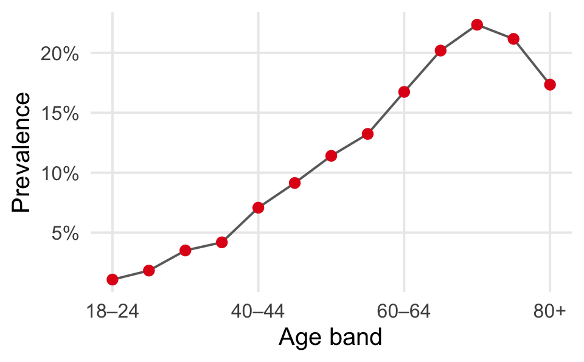

Age From 1% at 18–24 to over 20% in the 70s. Only 13.8% overall: few positives.

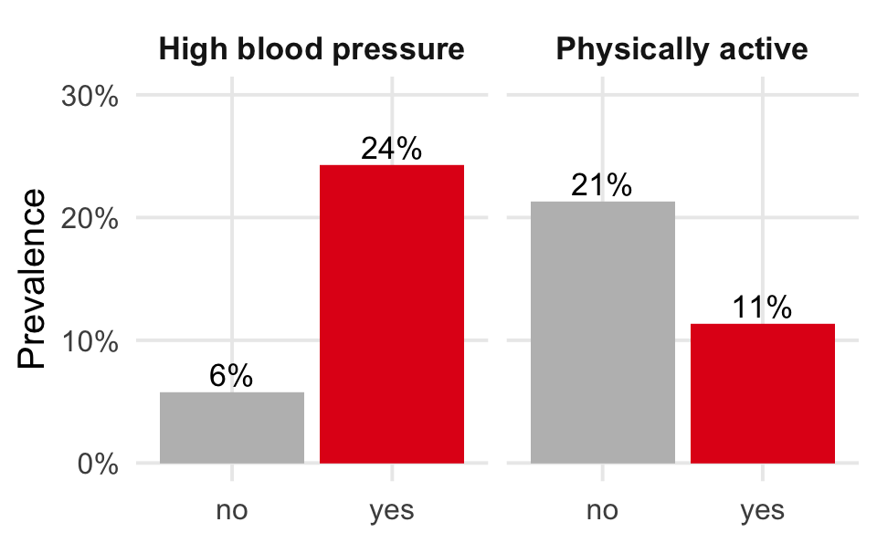

Conditions and lifestyle Four times the prevalence with high blood pressure. Half with physical activity. Plots suggest; a model can **hold the others fixed**. Part II.

# Logistic regression

Part II

From a line to an S-curve · probabilities · thresholds · odds

## Predicting yes or no

Warm-upI · EDAII · LogisticIII · EvaluationWrap-up

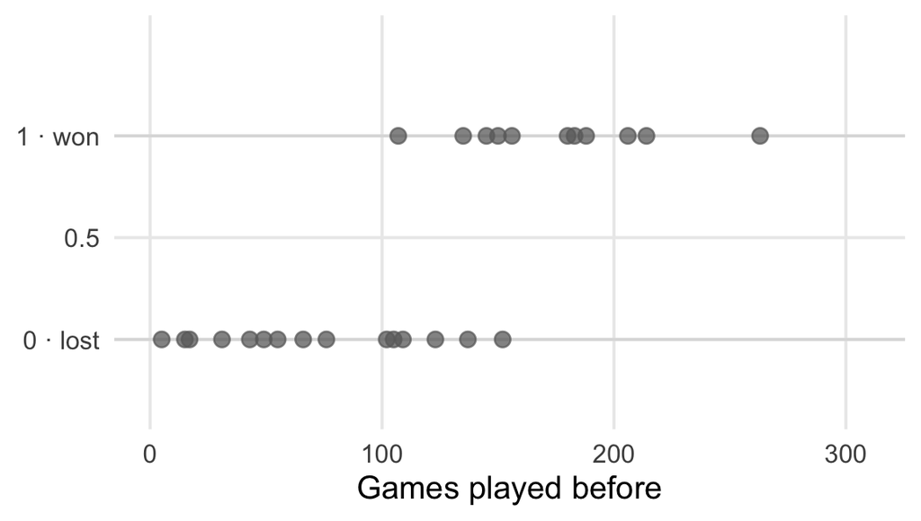

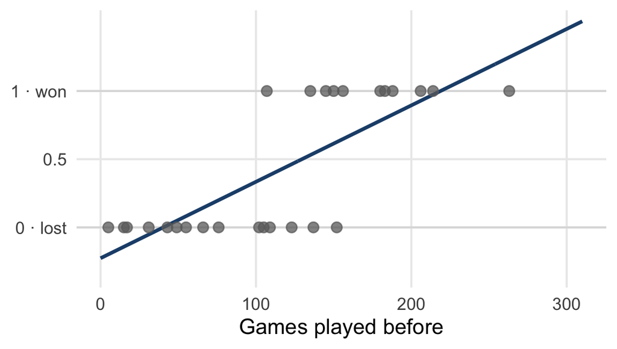

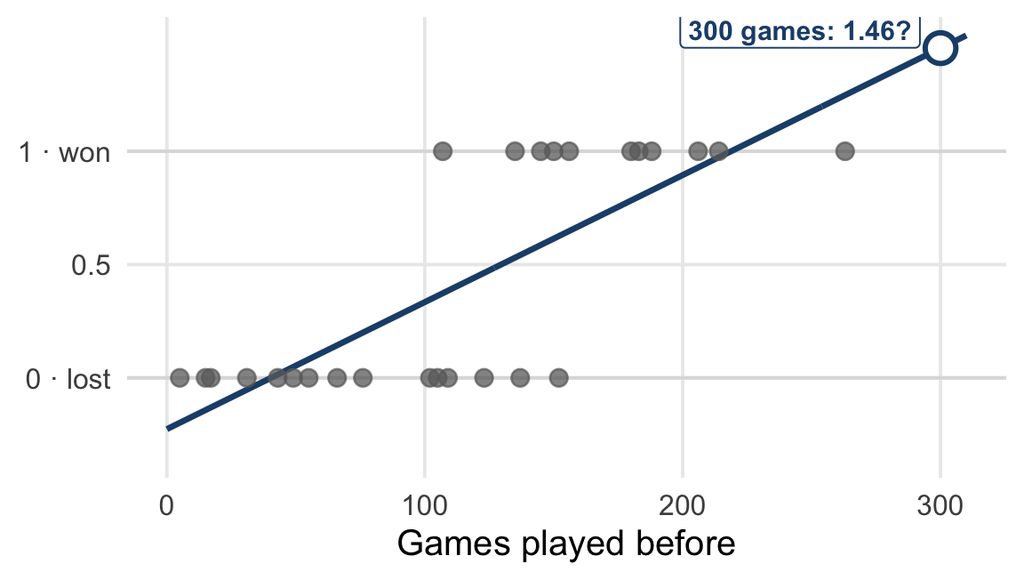

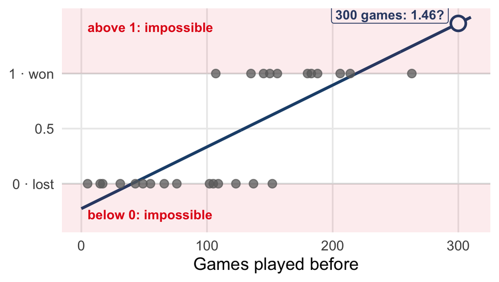

A made-up chess club: games played so far, and whether the next one was **won** (1) or **lost** (0).

What’s the chance a player wins? Let’s fit a line, like last week.

New player300 games played

The line says1.46 a 146% chance?

A line doesn’t know when to stop A probability lives between 0 and 1. A line runs off to ±∞.

## Squish the line: the S-curve

Warm-upI · EDAII · LogisticIII · EvaluationWrap-up

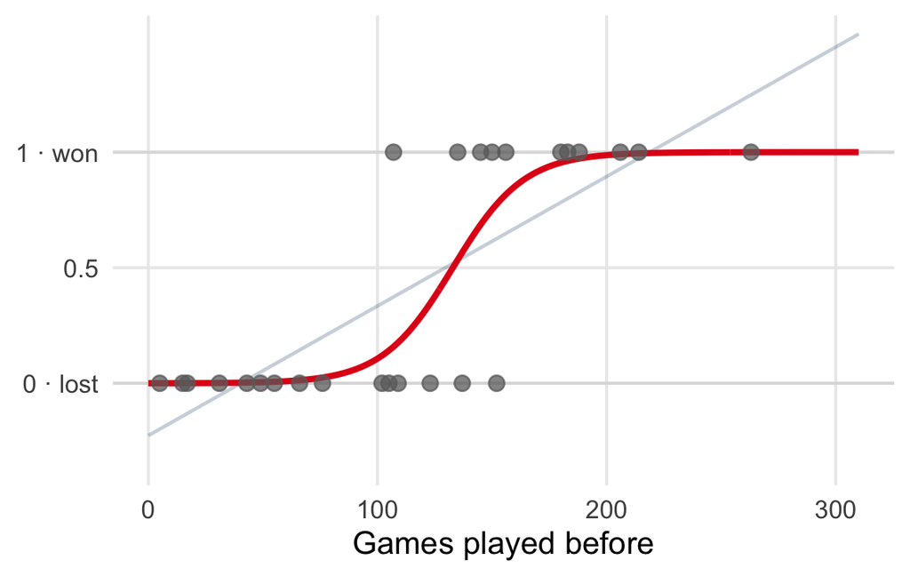

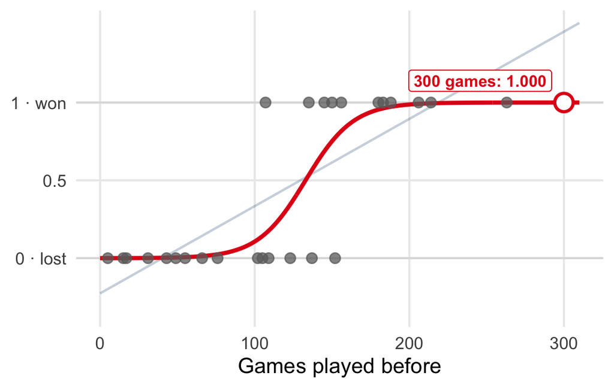

**Logistic regression** fits an S-shaped curve, the **sigmoid**: flat near 0 for beginners, flat near 1 for veterans, steep in between.

New player300 games played

The curve says1.000 close to 1, never above it

What comes out A **probability**: the chance that the outcome is 1. In R this column is called `.pred_1`.

## From probability to class: the threshold

Warm-upI · EDAII · LogisticIII · EvaluationWrap-up

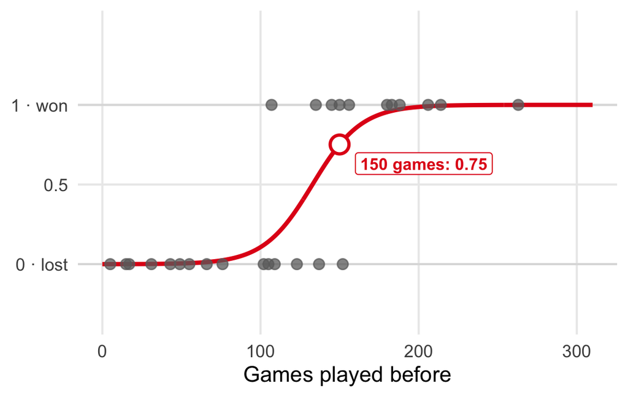

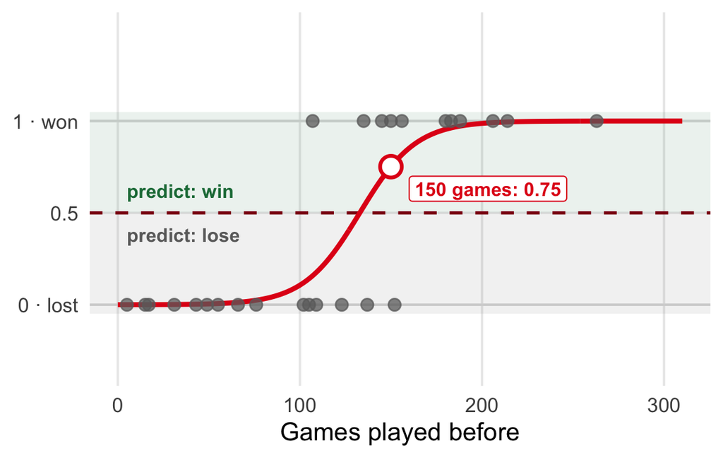

New player150 games: *p̂* = 0.75

Threshold0.5

Rule0.75 > 0.5 → predict **win**

0.5 is a choice, not a law Who says it should be 0.5? When the 1s are rare, as with diabetes, it often shouldn’t be. Part III moves it.

## What the model learns: two dials

Warm-upI · EDAII · LogisticIII · EvaluationWrap-up

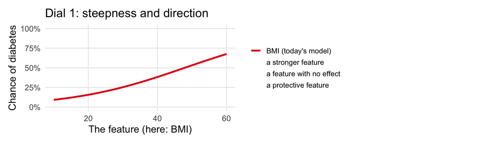

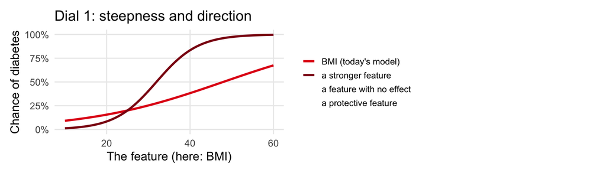

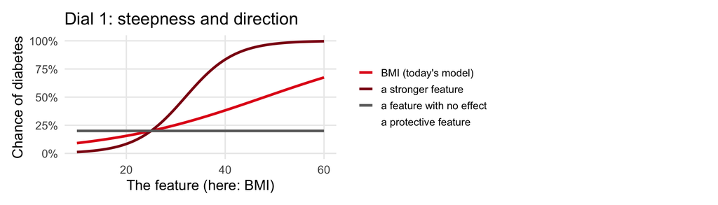

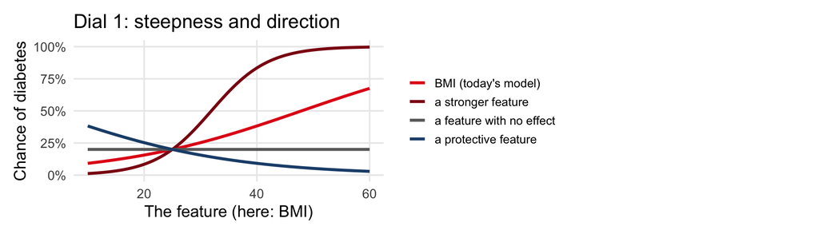

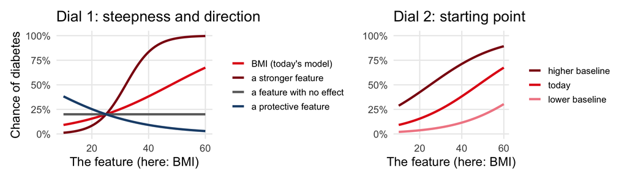

How much it matters A steeper S: the chance changes faster as the feature rises. Flat: the feature makes no difference.

Which way Rising: more of the feature, more risk. Falling: more of the feature, less risk.

Where it starts The baseline risk before the feature does anything. These dials are the coefficients `summary()` prints, on the **log-odds** scale; `exp()` turns each into an **odds ratio**.

## Reading a coefficient: the odds ratio

Warm-upI · EDAII · LogisticIII · EvaluationWrap-up

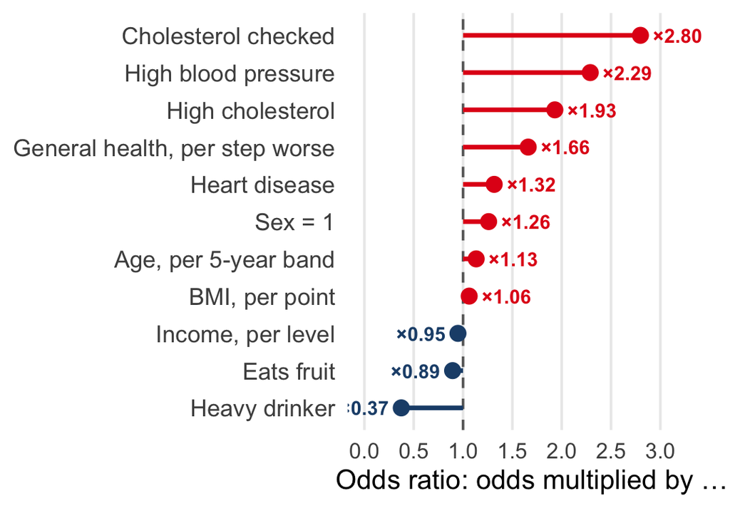

Odds ratio (OR) = exp(estimate) **Odds**: a 1-in-10 chance is odds of 1 to 9. The **OR** multiplies the odds. High blood pressure: 2.29.

Read it like this Above 1: higher odds; below 1: lower; 1: no difference. BMI 1.06: 6% higher odds per point. Heavy drinker 0.37: 63% lower.

What OR 2.29 means for a person A 10% chance becomes about 20% with high blood pressure, all else equal: roughly double, when the risk is small.

## Exercises: Part II

Part II · Q1–Q4 · lines 176–208

1. **Line 178, Q1:** one sentence: why not score on the training set?
2. **Line 183, Q2:** split 75/25 with `strata = diabetes`
3. **Line 197, Challenge:** fit a logistic regression on `train`
4. **Line 202, Q3:** should all variables go in? One sentence
5. **Line 207, Q4:** print the coefficient table with `summary()`

Lab 3 code, changed for today

```r
set.seed(123)                       # same split every time
split_grid <- initial_split(diabetes_data, prop = 0.75,
                            strata = diabetes)  # NEW: same share
train <- training(split_grid)       #   of 1s in both sets
test  <- testing(split_grid)

model <-
  logistic_reg() |>                 # was: linear_reg()
  fit(diabetes ~ ., data = train)   # outcome ~ every other column

model |>
  extract_fit_engine() |>           # pull out R's glm object
  summary()                         # so summary() can print it
```

**Stuck?**

- *For a classification model, the outcome should be a factor*: run Step 3 (line 93) first
- `summary(model)` prints little: add `extract_fit_engine()` in between, as in Lab 3
- The default engine is `glm`: no `set_engine()` needed

## Solutions: Part II

```r
set.seed(123)
split_grid <- initial_split(diabetes_data, prop = 0.75,
                            strata = diabetes)
train <- training(split_grid)
test <- testing(split_grid)

model <-
  logistic_reg() |>
  fit(diabetes ~ ., data = train)

model |>
  extract_fit_engine() |>
  summary()
```

Split with the outcome as strata, fit the logistic regression on the training rows, print the coefficients.

19,025 training rows, 6,343 test rows. Thanks to `strata`, both have the same share with diabetes, 13.8%.

```
# A tibble: 4 × 4
# Groups:   set [2]
  set   diabetes     n share
  <chr> <fct>    <int> <dbl>
1 train 0        16405 0.862
2 train 1         2620 0.138
3 test  0         5469 0.862
4 test  1          874 0.138
```

`fit()` sets the dials: one coefficient per feature plus the intercept. For now, read only the **sign**: positive means more risk.

```
# A tibble: 20 × 2
  term                    estimate
  <chr>                      <dbl>
1 (Intercept)               -7.53
2 high_bp1                   0.828
3 high_chol1                 0.658
4 chol_check1                1.03
5 bmi                        0.06
6 smoker1                   -0.078
7 stroke1                    0.061
8 heart_diseaseor_attack1    0.274
# ℹ 12 more rows
```

The coefficient table from `summary()`: estimate, *z* value and p-value (the standard error is left out to fit), as in Lab 3 with *z* instead of *t*. Sorted by p-value here: general health, BMI, blood pressure, cholesterol, age.

```
              Estimate     z        p
(Intercept)     -7.534 -22.5 3.5e-112
gen_hlth         0.507  18.5  1.0e-76
bmi              0.060  18.3  1.9e-74
high_bp1         0.828  15.0  3.7e-51
high_chol1       0.658  12.9  2.5e-38
age              0.125  12.3  6.6e-35
hvy_alcohol…1   -0.984  -6.4  1.2e-10
sex1             0.231   4.6  3.3e-06
```

Step 3 shows the 8 rows with the smallest p-values; `summary()` prints all 20 in column order, plus the deviance and AIC below.

## Reading the output

Warm-upI · EDAII · LogisticIII · EvaluationWrap-up

**Notebook** lines 210–235 class discussion: write the answers into the four boxes*discuss*

Estimate The change in the **log-odds** per unit of the feature; its **sign** says which way. `exp(estimate)` is the **odds ratio**: `gen_hlth` OR 1.66 per step towards “poor” health.

p-value As last week: if the true effect were 0, how surprising is this estimate? `high_bp`, `bmi`, `gen_hlth`, `age`: extremely. `smoker`, `phys_activity`: not, once the rest is held fixed.

Careful Heavy drinkers: odds × 0.37, “63% lower”. Does alcohol protect? More likely people with diabetes are told to stop drinking. **Association, not cause.**

Box 4: which metrics? Not accuracy: only 14% have diabetes, so “no” for everyone is already 86% right. Part III gives the alternatives.

p-values say what’s associated. They don’t say whether the model **predicts** well.

# Evaluation

Part III

Is the model any good? · confusion matrix · precision · recall · thresholds

## Predictions, piece by piece

Warm-upI · EDAII · LogisticIII · EvaluationWrap-up

**Notebook** lines 241–251 Q1 at line 242, Q2 at line 250*code together*

train_preds <- model |> augment(new_data = train) test_preds <- model |> augment(new_data = test) pull(test_preds, .pred_1)[1:10]

1. **Add predictions** to a table, as last week. For a classifier you get three new columns: `.pred_class` (0 or 1), `.pred_0` and `.pred_1` (the two probabilities).
2. **Both sets**: the training set for choosing a threshold later (Q7), the test set for the final check (Q10).
3. **Take one column out** of a table as a plain vector.
4. **The first ten** elements of that vector.

Q2 output0.008 0.143 0.102 0.259 0.390 0.019 …

Q2 answerprobabilities, not classes: we need a cut-off the threshold from the S-curve

## The threshold, in code

Warm-upI · EDAII · LogisticIII · EvaluationWrap-up

**Notebook** lines 257–259 Q3: threshold 0.5, both sets*code together*

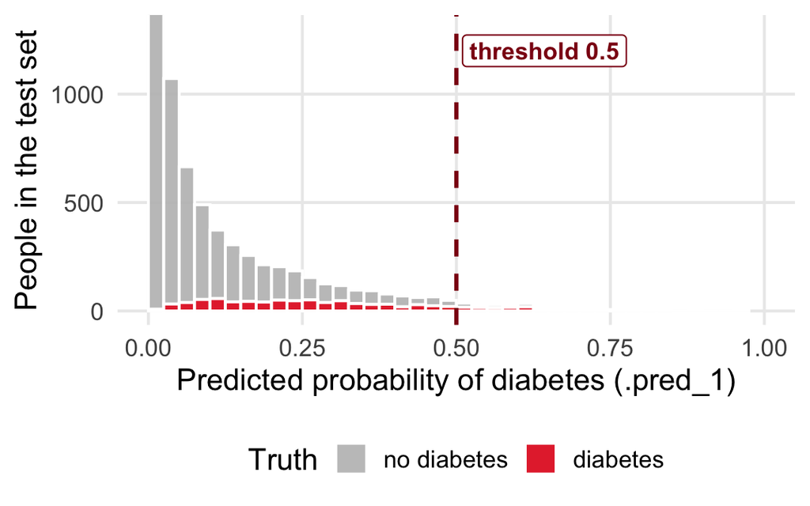

test_preds <- test_preds |> mutate(.pred_class = as.factor( if_else(.pred_1 > 0.5, 1, 0)))

1. **Make it a factor**, like the truth column, so the two can be compared.
2. **The threshold**: above 0.5 is a 1, otherwise a 0. This overwrites `augment()`’s own `.pred_class`, which used 0.5 too; now the rule is in plain sight.

Look where the mass is Only 3.8% of people get a probability above 0.5. Most of the red bars, people who **do** have diabetes, sit left of the line.

## The confusion matrix

Warm-upI · EDAII · LogisticIII · EvaluationWrap-up

**Notebook** lines 263–269 Q4: one chunk for the training set, one for the test set*code together*

Truth: diabetes

Truth: no diabetes

Predicted: diabetes

**True positive (TP)**136has diabetes, flagged

**False positive (FP)**106healthy, flagged anyway: a false alarm

Predicted: no diabetes

**False negative (FN)**738has diabetes, missed

**True negative (TN)**5,363healthy, correctly left alone

`test_preds |> conf_mat(truth = diabetes, estimate = .pred_class) |> autoplot(type = "heatmap")`: **truth** is the real column, **estimate** our class; `autoplot()` draws the table as a heatmap. R puts the 0 class first, so its top-left cell is the true negatives.

Read it Of 874 people with diabetes in the test set, the model flags 136 and **misses 738**.

## Q5: five numbers from one table

Warm-upI · EDAII · LogisticIII · EvaluationWrap-up

**Notebook** line 273 how would you evaluate whether this model is good or bad?*discuss*

Accuracy(TP + TN) / all = (136 + 5,363) / 6,343 = 0.867 share we got right

RecallTP / (TP + FN) = 136 / 874 = 0.156 share of the sick we find · also called **sensitivity**

PrecisionTP / (TP + FP) = 136 / 242 = 0.562 share of our flags that are right

SpecificityTN / (TN + FP) = 5,363 / 5,469 = 0.981 share of the healthy we leave alone

F12 × P × R / (P + R) = 0.244 high only if both P and R are

The accuracy trap, again Predict “no diabetes” for **everyone**: accuracy 0.862. Our model: 0.867. Barely better than doing nothing.

What our model really does Very good at leaving the healthy alone (0.981). When it flags someone it’s right about half the time (0.562). It **finds only 16%** of people with diabetes.

## Which mistake is worse?

Warm-upI · EDAII · LogisticIII · EvaluationWrap-up

**Notebook** lines 275–280 discuss with your table partners*discuss*

The model decides who gets invited for a free diabetes blood test. Which is worse, a false positive or a false negative?

Screening: miss nobody A **false negative** is a person with diabetes who is never tested. A **false positive** costs one blood test. We want high **recall**, and accept lower precision.

Treatment: be sure If a flag meant starting medication straight away, a **false positive** treats a healthy person. Then **precision** matters more.

“Good” depends on what the predictions are used for. The threshold is how we choose.

## Q6: moving the threshold

Warm-upI · EDAII · LogisticIII · EvaluationWrap-up

**Notebook** line 288 what's wrong with 0.8? what happens if α goes up, or down?*discuss*

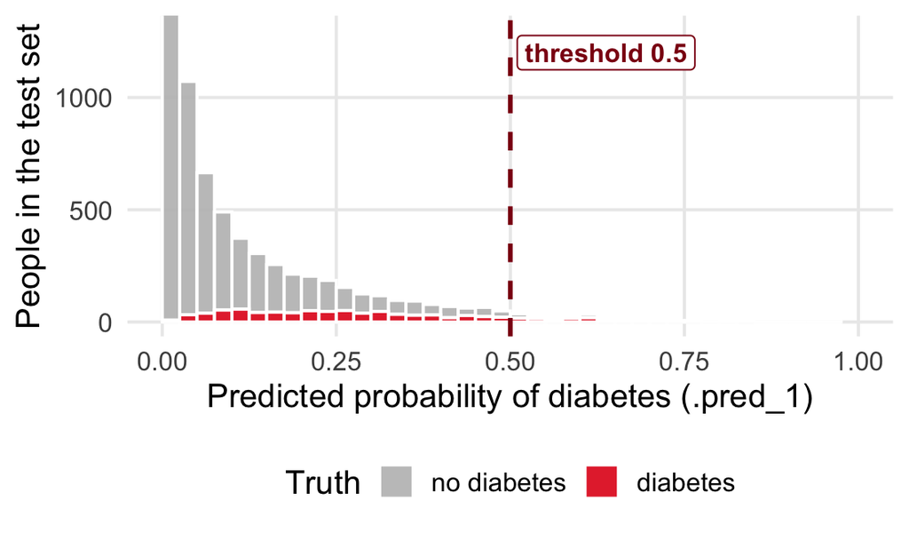

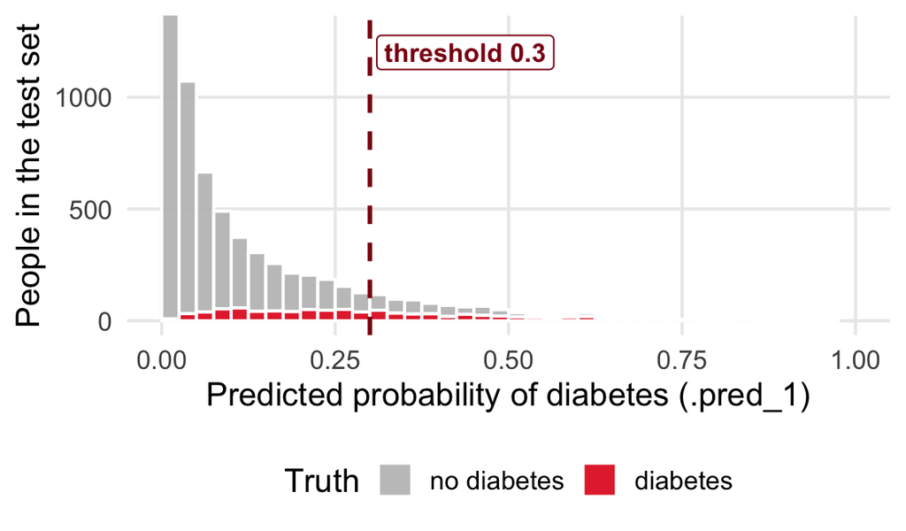

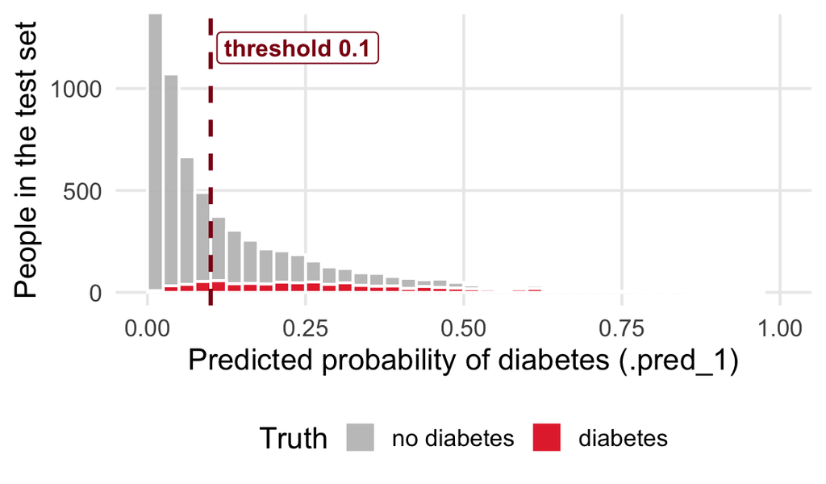

α = 0.5find 136 of 874, 106 false alarms

α = 0.3find 371, 500 false alarms

α = 0.1find 742, 1,944 false alarms

The trade-off **Lower** α: more people flagged, recall **up**, precision **down**. **Raise** it: the reverse.

And 0.8? Hardly anyone gets a probability that high: recall close to 0.

## Q7 in code, piece by piece

Warm-upI · EDAII · LogisticIII · EvaluationWrap-up

**Notebook** line 293 Q7: precision, recall and F1 on the training set for 7 thresholds*code together*

alpha_list <- c(0.1, 0.2, 0.3, 0.4, 0.5, 0.6, 0.7) class_metrics <- metric_set(precision, recall, f_meas) class_metrics <- partial(class_metrics, event_level = "second") ev_metrics <- map_dfr( alpha_list, ~ augment(model, new_data = train) |> mutate(.pred = as.factor(if_else(.pred_1 > .x, "1", "0"))) |> class_metrics(truth = diabetes, estimate = .pred) |> mutate(alpha = .x), .id = NULL)

1. **Three metrics in one function**, like `metric_set(rsq, rmse)` last week. `f_meas` is F1.
2. **Score the 1s**, the **second** level. Without it R scores the 0s. `partial()` sets it once.
3. **Run once per threshold** in `alpha_list`; stack the results.
4. **The code to run**: predictions on the **training** set…
5. …cut at the current threshold, `.x`.
6. **Label each row** with its threshold, for the plot.

## Exercises: Part III

Part III · Q8–Q10 · lines 300–320

1. **Line 301, Q8:** plot the three metrics against α, one colour per metric
2. **Line 309, Q9:** precision–recall plot: recall on x, precision on y, one point per α. What’s the trade-off?
3. **Line 319, Q10:** take the α with the best training F1; compute F1 on the **test** set at that α. Did the model overfit?

Syntax you need

```r
# Q8: ev_metrics is long: one row per alpha and metric
ev_metrics |>
  ggplot(aes(alpha, .estimate, colour = .metric)) +
  geom_line() + geom_point()

# Q9: one column per metric, so each can be an axis
ev_metrics |>
  pivot_wider(id_cols = alpha, names_from = .metric,
              values_from = .estimate) |>
  ggplot(aes(x = recall, y = precision)) + geom_point()

# Q10: the alpha in the row with the largest F1
best_alpha <- ev_metrics |>
  filter(.metric == "f_meas") |>
  slice_max(.estimate) |>    # keep the top row
  pull(alpha)                # take out the number
# then Q7's mutate() with best_alpha on test,
# and f_meas(..., event_level = "second")
```

**Stuck?**

- Q9 looks empty? Check the column names after `pivot_wider()`: `precision`, `recall`, `f_meas`
- Q10 F1 near 0.9? `event_level = "second"` is missing

## Solutions: Q8

```r
ev_metrics

ev_metrics |>
  mutate(.metric = if_else(.metric == "f_meas", "F1-Score",
                           str_to_title(.metric))) |>
  ggplot(aes(alpha, .estimate, colour = .metric)) +
  geom_line(linetype = "dashed") +
  geom_point() +
  scale_colour_uchicago() +
  labs(x = "Probability threshold",
       y = "Evaluation metric estimate",
       colour = "Evaluation metric")
```

Q7’s table, then the Q8 plot of it.

Q7’s result: one row per threshold and metric, 21 in all. Shown side by side here: as α rises, precision rises and recall falls.

```
# A tibble: 7 × 4
  alpha precision recall f_meas
  <dbl>     <dbl>  <dbl>  <dbl>
1   0.1     0.276  0.85   0.416
2   0.2     0.363  0.644  0.464
3   0.3     0.43   0.445  0.438
4   0.4     0.493  0.282  0.359
5   0.5     0.532  0.155  0.24
6   0.6     0.577  0.076  0.134
7   0.7     0.555  0.025  0.048
```

`mutate()` only tidies the legend labels (`f_meas` → F1-Score, `precision` → Precision). Recall falls off a cliff as α rises; F1 peaks at α = 0.2.

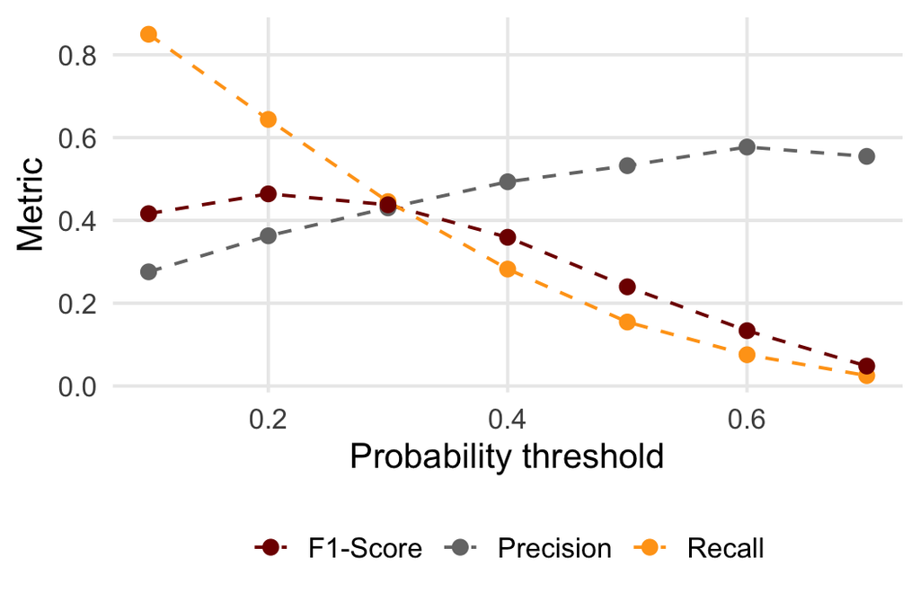

Step 1 is shown with `pivot_wider()` to fit the slide.

## Solutions: Q9 and Q10

```r
ev_metrics |>
  filter(.metric %in% c("precision", "recall")) |>
  pivot_wider(id_cols = alpha, names_from = .metric,
              values_from = .estimate) |>
  ggplot(aes(x = recall, y = precision)) +
  geom_point() +
  geom_text(aes(label = paste0("α = ", alpha)),
            position = position_nudge(x = -0.045)) +
  geom_line(linetype = "dashed")

best_alpha <- ev_metrics |>
  filter(.metric == "f_meas") |>
  slice_max(.estimate) |>
  pull(alpha)

model |>
  augment(new_data = test) |>
  mutate(prediction = if_else(.pred_1 > best_alpha, 1, 0),
         prediction = as.factor(prediction)) |>
  f_meas(truth = diabetes, estimate = prediction,
         event_level = "second")
```

Q9 reshapes and plots; Q10 picks the best α on the training set and tests it.

Keep two metrics, then `pivot_wider()`: one row per α, one column per metric.

```
# A tibble: 7 × 3
  alpha precision recall
  <dbl>     <dbl>  <dbl>
1   0.1     0.276  0.85
2   0.2     0.363  0.644
3   0.3     0.43   0.445
4   0.4     0.493  0.282
5   0.5     0.532  0.155
6   0.6     0.577  0.076
7   0.7     0.555  0.025
```

Each point is a threshold. Lower α moves right: more of the sick found (recall), less sure about each flag (precision).

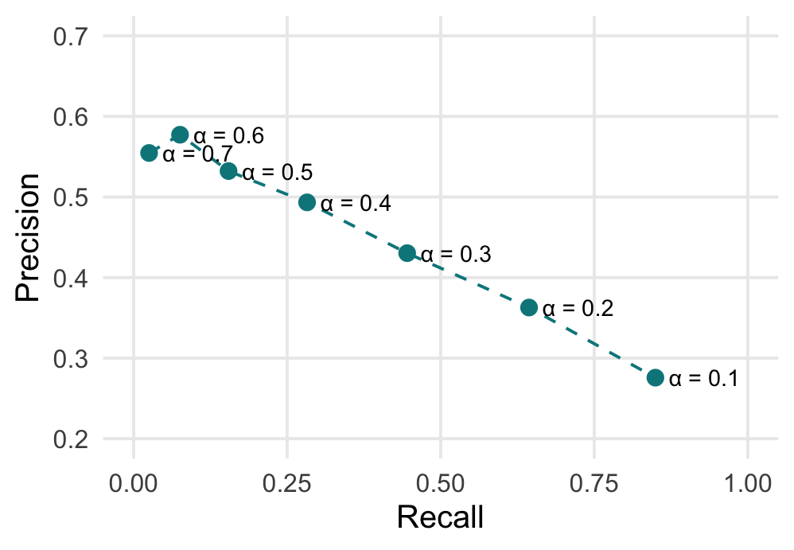

`filter()` keeps the F1 rows, `slice_max()` the best one, `pull()` takes out its α.

```
[1] 0.2
```

Same cut-off rule as Q3, now at α = 0.2, on the test set: F1 0.462, against 0.464 on the training set. **No overfitting**.

```
# A tibble: 1 × 3
  .metric .estimator .estimate
  <chr>   <chr>          <dbl>
1 f_meas  binary         0.462
```

## Part III: what did we learn?

Warm-upI · EDAII · LogisticIII · EvaluationWrap-up

F1 one number for precision and recall

α 0.5, train**0.240**

α 0.2, train**0.464**

α 0.2, test**0.462**

Test, α = 0.2find 558 of 874, 981 false alarms

Per person found1.8 false alarms

Same model, better use Nothing was refitted. Moving α from 0.5 to 0.2 almost doubles F1 and raises recall from 0.15 to 0.64 (training set).

No overfitting Training and test F1 are almost identical. A model with 20 coefficients on 19,000 rows has little room to memorise.

Still not great F1 under 0.5: the features overlap a lot between the two groups. A better threshold can’t fix that; better features or models might.

## Summary

Warm-upI · EDAII · LogisticIII · EvaluationWrap-up

**1****Logistic regression** bends a line into an S-curve, so predictions are probabilities between 0 and 1. A coefficient is a change in the **log-odds**: its sign says which way, and `exp()` turns it into an **odds ratio**. For classification the outcome must be a **factor**

**2**A **threshold** turns probabilities into classes. 0.5 is only a default: choose it on the training set, check it on the test set

**3**With imbalanced classes **accuracy flatters**. Read the confusion matrix: **recall** (how many of the 1s we find) and **precision** (how many of our flags are right) trade off as the threshold moves

**Question:** you’re designing the screening programme. Which threshold, and how many false alarms per person found would you accept?

## Further reading

- The completed notebook goes up after class.
- [*An Introduction to Statistical Learning*](https://www.statlearning.com): chapter 4, sections 4.1–4.3 (logistic regression). Free PDF.
- [*Tidy Modeling with R*](https://www.tmwr.org): chapter 9 (judging model effectiveness).
- The [yardstick metric reference](https://yardstick.tidymodels.org/reference/), for every metric in today’s lab.

## 30 seconds of feedback

[figure not shown]

How was today’s lab? Scan the code, or open forms.gle/i3uobCAaGmkzf1ns7. It takes 30 seconds and changes what next week looks like.